# lab_5

Hollie Pennington

10/25/2021

##Part 1: Confidence intervals

In this section, we’ll use the ‘t.test()’ function to calculate confidence intervals.

### Example 1

Create a single mock sample containing a number of values, then learn to use ‘t.test()’ to return confidence intervals, and learn about in-line code referencing so our text becomes more reproducible, too.

```r
# Create a mock sample

otter_lengths <- c(30, 45, 28, 31, 34, 46, 52, 29)

# Find the confidence interval:

otter_ci <- t.test(otter_lengths)

# Find the standard deviation
otter_sd <- sd(otter_lengths)
```

Mean otter length is 36.9 inches $\pm$ 9.3 (mean $\pm$ sd, n = 8) with a 95% confidence interval of [29.1, 44.7] inches.

#### Now, using in-line referencing

Mean otter length is 36.9 inches with a 95% confidence interval of [29.1, 44.7] inches.

## Part 2: Two-sample t-tests

### Example 1

Make two mock samples, and ask the question: do we have sufficient evidence to make us reject the null hypothesis that these samples were drawn from populations with the same mean?

```r
# make my mock samples
oak_trees <- c(20, 19, 24, 28, 34, 12, 15, 25)

pine_trees <- c(39, 26, 20, 30, 37, 22, 19, 18)

#two-sample t-test
trees_t <- t.test(oak_trees, pine_trees)

# Null hypothesis: mean heights are the same
# ie.: Trees are drawn from populations with the same mean height
```

If these populations have same mean height there is 28.7% chance that the samples we choose will be at least this different. This is not evidence to reject the null hypothesis. This difference is not very unusual.

# in a report you would write:

“t(df) = t-statistic, p = p-value”

*AVOID*: p = 0

When things get really small (usually p < 0.001)

## Part 3: Another t-test with cars data

Using the `mpg` dataset

### Take a look at the data

```r
compact_suv <- mpg %>%
  filter(class %in% c("compact", "suv"))

#check for remaining levels
unique(compact_suv$class)
```

```
## [1] "compact" "suv"
```

Create a histogram of city gas mileage (cty) faceted by class starting from compact_suv.

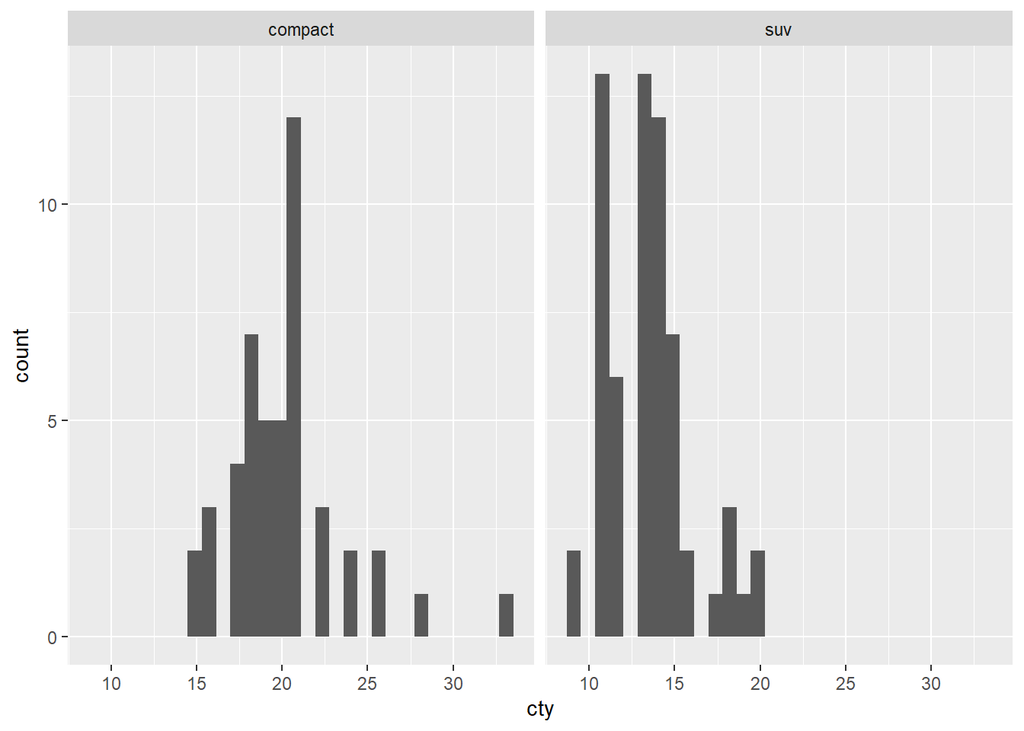

```r
ggplot(data = compact_suv, aes(x = cty)) +
  geom_histogram() +
  facet_wrap(~ class)
```